# Regression Model Quiz

This quiz is part of Algoritma Academy assessment process. Congratulations on completing the Regression Model course! We will conduct an assessment quiz to test practical regression model techniques you have learned on the course. The quiz is expected to be taken in the classroom, please contact our team of instructors if you missed the chance to take it in class.

## Data Exploration

In this quiz, you will be using criminologist dataset (`crime`). If you have been following along in the course you can use the one that has already been loaded in the environment or you can run the following chunk in your RMarkdown to make sure we are using a same column names:

```r
crime <- read.csv("crime.csv")
colnames(crime) <- c("percent_m", "is_south", "mean_education", "police_exp60", "police_exp59", "labour_participation", "m_per1000f", "state_pop", "nonwhites_per1000", "unemploy_m24", "unemploy_m39", "gdp", "inequality", "prob_prison", "time_prison", "crime_rate")
```

To make sure you have loaded the data correctly, do a simple inspection of the data. Try to peek in using `head` or `tail` and see if the columns have been stored in its appropriate data types.

```r
# your code here
head(crime)
```

```
##   percent_m is_south mean_education police_exp60 police_exp59
## 1       151        1             91           58           56
## 2       143        0            113          103           95
## 3       142        1             89           45           44
## 4       136        0            121          149          141
## 5       141        0            121          109          101
## 6       121        0            110          118          115
##   labour_participation m_per1000f state_pop nonwhites_per1000 unemploy_m24
## 1                  510        950        33               301          108
## 2                  583       1012        13               102           96
## 3                  533        969        18               219           94
## 4                  577        994       157                80          102
## 5                  591        985        18                30           91
## 6                  547        964        25                44           84
##   unemploy_m39 gdp inequality prob_prison time_prison crime_rate
## 1           41 394        261    0.084602     26.2011        791
## 2           36 557        194    0.029599     25.2999       1635
## 3           33 318        250    0.083401     24.3006        578
## 4           39 673        167    0.015801     29.9012       1969
## 5           20 578        174    0.041399     21.2998       1234
## 6           29 689        126    0.034201     20.9995        682
```

```r
str(crime)
```

```
## 'data.frame':    47 obs. of  16 variables:
##  $ percent_m           : int  151 143 142 136 141 121 127 131 157 140 ...
##  $ is_south            : int  1 0 1 0 0 0 1 1 1 0 ...
##  $ mean_education      : int  91 113 89 121 121 110 111 109 90 118 ...
##  $ police_exp60        : int  58 103 45 149 109 118 82 115 65 71 ...
##  $ police_exp59        : int  56 95 44 141 101 115 79 109 62 68 ...
##  $ labour_participation: int  510 583 533 577 591 547 519 542 553 632 ...
##  $ m_per1000f          : int  950 1012 969 994 985 964 982 969 955 1029 ...
##  $ state_pop           : int  33 13 18 157 18 25 4 50 39 7 ...
##  $ nonwhites_per1000   : int  301 102 219 80 30 44 139 179 286 15 ...
##  $ unemploy_m24        : int  108 96 94 102 91 84 97 79 81 100 ...
##  $ unemploy_m39        : int  41 36 33 39 20 29 38 35 28 24 ...
##  $ gdp                 : int  394 557 318 673 578 689 620 472 421 526 ...
##  $ inequality          : int  261 194 250 167 174 126 168 206 239 174 ...
##  $ prob_prison         : num  0.0846 0.0296 0.0834 0.0158 0.0414 ...
##  $ time_prison         : num  26.2 25.3 24.3 29.9 21.3 ...
##  $ crime_rate          : int  791 1635 578 1969 1234 682 963 1555 856 705 ...
```

Among all variables within our `crime` dataset, there is a `crime_rate` variable that describes the measure of crime rate of the United States in 1960 from different states. Imagine you’re working as a government analyst and would like to see how social-economic conditions could reflect on the crime rate in a state. Recall how we can inspect the correlation for each variable using `cor` or `ggcorr` from `GGally` package. Try it out on your own and see what are the possible predictor variables for our `crime_rate` variable.

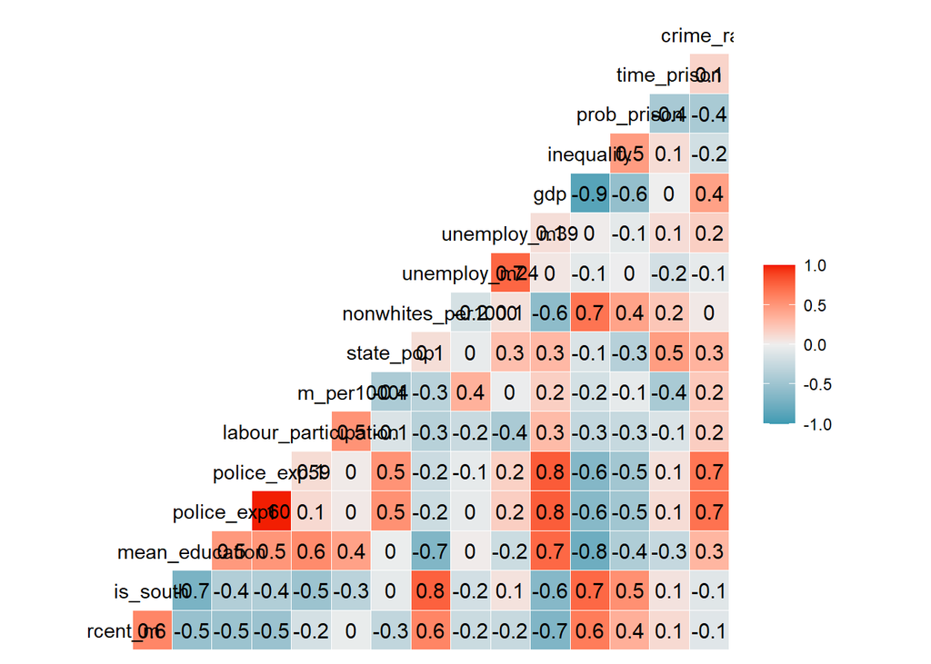

```r
# your code here
library(GGally)
ggcorr(crime, label = T)
```

Based on the result of the previous chunk, you should know each variable’s correlation with `crime_rate` variable. Referring to the value, we can perform a preliminary variable selection for a suitable predictor variable. *1. Which variable has little to no correlation with our `crime_rate` variable and might not be suitable as a predictor variable? - [ ] crime_rate - [ ] police_exp59 - [ ] unemploy_m39 - [x] nonwhites_per1000*

## Building Linear Regression

From the data exploration process and the correlation information of our dataset, it is known that not all variables show a strong correlation with `crime_rate` variable. Let’s try to build a simple linear model using one of the highly correlated variables: `police_exp59`. Create a regression model using `lm()` function to predict `crime_rate` using `police_exp59` from our dataset and assign it to an object named `model_crime`.

```r
# your code here
crime_model <-  lm(crime_rate ~ police_exp59, crime)

crime_model
```

```
##
## Call:
## lm(formula = crime_rate ~ police_exp59, data = crime)
##
## Coefficients:
##  (Intercept)  police_exp59
##      165.164         9.222
```

```r
summary(crime_model)
```

```
##
## Call:
## lm(formula = crime_rate ~ police_exp59, data = crime)
##
## Residuals:
##     Min      1Q  Median      3Q     Max
## -595.58 -156.76   12.29  146.74  593.74
##
## Coefficients:
##              Estimate Std. Error t value Pr(>|t|)
## (Intercept)   165.164    130.427   1.266    0.212
## police_exp59    9.222      1.537   6.001 3.11e-07 ***
## ---
## Signif. codes:  0 '***' 0.001 '**' 0.01 '*' 0.05 '.' 0.1 ' ' 1
##
## Residual standard error: 291.4 on 45 degrees of freedom
## Multiple R-squared:  0.4445, Adjusted R-squared:  0.4322
## F-statistic: 36.01 on 1 and 45 DF,  p-value: 3.114e-07
```

2. Which of the following best describes the slope?
- It’s a negative slope, and is statistically insignificant (P-value higher than 0.05)
- It’s a positive slope, and is statistically significant (P-value lower than 0.05)
- It’s a positive slope, and is statistically insignificant (P-value higher than 0.05)
- It’s a negative slope, and is statistically significant (P-value lower than 0.05)
3. What is the most fitting conclusion from the regression model above?
- The R-squared does not tell us about the quality of our model fit, we should use p-value instead
- The R-squared approximates 0.44, indicating a reasonable fit (the closer to 0 the better)
- The R-squared approximates 0.44, indicating a poor fit (the closer to 1 the better) ___

## Feature Selection using Stepwise Regression

The R-squared of `model_crime` approximates 0.44, which ideally needs to be improved upon by, for example, adding more predictor variables. One of the techniques for selecting predictor variables is using stepwise regression algorithm. Use the `step()` function with `direction="backward"` parameter and store the best model estimate under the `model_step` object.

```r
# your code here
full_model <- lm(crime_rate ~ . , crime)

model_step <- step(full_model, direction = "backward")
```

```
## Start:  AIC=514.65
## crime_rate ~ percent_m + is_south + mean_education + police_exp60 +
##     police_exp59 + labour_participation + m_per1000f + state_pop +
##     nonwhites_per1000 + unemploy_m24 + unemploy_m39 + gdp + inequality +
##     prob_prison + time_prison
##
##                        Df Sum of Sq     RSS    AIC
## - is_south              1        29 1354974 512.65
## - labour_participation  1      8917 1363862 512.96
## - time_prison           1     10304 1365250 513.00
## - state_pop             1     14122 1369068 513.14
## - nonwhites_per1000     1     18395 1373341 513.28
## - m_per1000f            1     31967 1386913 513.74
## - gdp                   1     37613 1392558 513.94
## - police_exp59          1     37919 1392865 513.95
## <none>                              1354946 514.65
## - unemploy_m24          1     83722 1438668 515.47
## - police_exp60          1    144306 1499252 517.41
## - unemploy_m39          1    181536 1536482 518.56
## - percent_m             1    193770 1548716 518.93
## - prob_prison           1    199538 1554484 519.11
## - mean_education        1    402117 1757063 524.86
## - inequality            1    423031 1777977 525.42
##
## Step:  AIC=512.65
## crime_rate ~ percent_m + mean_education + police_exp60 + police_exp59 +
##     labour_participation + m_per1000f + state_pop + nonwhites_per1000 +
##     unemploy_m24 + unemploy_m39 + gdp + inequality + prob_prison +
##     time_prison
##
##                        Df Sum of Sq     RSS    AIC
## - time_prison           1     10341 1365315 511.01
## - labour_participation  1     10878 1365852 511.03
## - state_pop             1     14127 1369101 511.14
## - nonwhites_per1000     1     21626 1376600 511.39
## - m_per1000f            1     32449 1387423 511.76
## - police_exp59          1     37954 1392929 511.95
## - gdp                   1     39223 1394197 511.99
## <none>                              1354974 512.65
## - unemploy_m24          1     96420 1451395 513.88
```

[output cut: 100 more lines]

```
##
## Step:  AIC=503.93
## crime_rate ~ percent_m + mean_education + police_exp60 + m_per1000f +
##     unemploy_m24 + unemploy_m39 + inequality + prob_prison
##
##                  Df Sum of Sq     RSS    AIC
## <none>                        1453068 503.93
## - m_per1000f      1    103159 1556227 505.16
## - unemploy_m24    1    127044 1580112 505.87
## - prob_prison     1    247978 1701046 509.34
## - unemploy_m39    1    255443 1708511 509.55
## - percent_m       1    296790 1749858 510.67
## - mean_education  1    445788 1898855 514.51
## - inequality      1    738244 2191312 521.24
## - police_exp60    1   1672038 3125105 537.93
```

```r
summary(model_step)
```

```
##
## Call:
## lm(formula = crime_rate ~ percent_m + mean_education + police_exp60 +
##     m_per1000f + unemploy_m24 + unemploy_m39 + inequality + prob_prison,
##     data = crime)
##
## Residuals:
##     Min      1Q  Median      3Q     Max
## -444.70 -111.07    3.03  122.15  483.30
##
## Coefficients:
##                 Estimate Std. Error t value Pr(>|t|)
## (Intercept)    -6426.101   1194.611  -5.379 4.04e-06 ***
## percent_m          9.332      3.350   2.786  0.00828 **
## mean_education    18.012      5.275   3.414  0.00153 **
## police_exp60      10.265      1.552   6.613 8.26e-08 ***
## m_per1000f         2.234      1.360   1.642  0.10874
## unemploy_m24      -6.087      3.339  -1.823  0.07622 .
## unemploy_m39      18.735      7.248   2.585  0.01371 *
## inequality         6.133      1.396   4.394 8.63e-05 ***
## prob_prison    -3796.032   1490.646  -2.547  0.01505 *
## ---
## Signif. codes:  0 '***' 0.001 '**' 0.01 '*' 0.05 '.' 0.1 ' ' 1
##
## Residual standard error: 195.5 on 38 degrees of freedom
## Multiple R-squared:  0.7888, Adjusted R-squared:  0.7444
## F-statistic: 17.74 on 8 and 38 DF,  p-value: 1.159e-10
```

4. Based on the summary of your final model, which statement is **incorrect**?
- An increase of 1 of police_exp60 causes the value of crime_rate to increase by 10,265
- An increase of 1 of unemploy_m24 causes the crime_rate to decrease by 6,087
- An increase of 1 of mean_education causes the value of crime_rate to decrease by 18.01
- Adjusted R-squared is a better metrics for evaluating our model compared to Multiple R-squared ___

## Shapiro test for Normality test

One of the assumptions for linear regression stated that the error obtained from the model must be distributed normally around the mean of 0. You will need to validate our normality assumption from `model_step` using `shapiro.test()` function. This function requires us to pass in the residuals of our model.

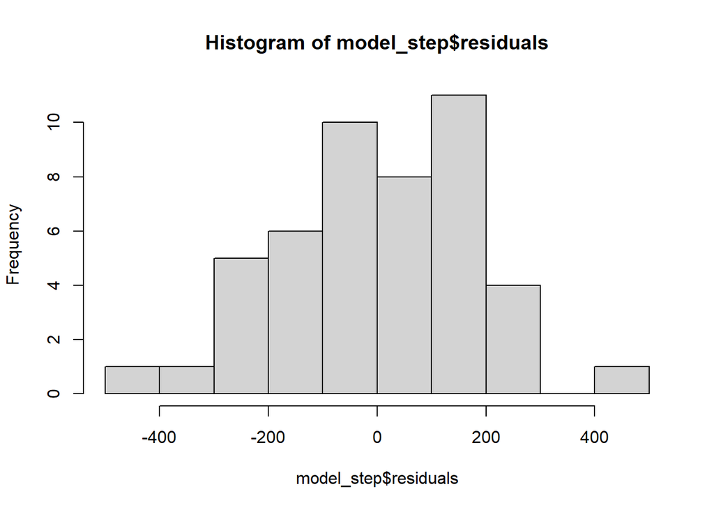

```r
hist(model_step$residuals)
```

```r
# your code here
shapiro.test(model_step$residuals)
```

```
##
##  Shapiro-Wilk normality test
##
## data:  model_step$residuals
## W = 0.98511, p-value = 0.8051
```

For your reference, Shapiro testing use the following hypotheses:

$H_0$ : Error is distributed normally

$H_1$ : Error is not distributed normally

5. Based on the Shapiro test you have performed, what conclusion can be drawn from the result?
- Error is distributed normally (P-value higher than 0.05)
- Error is distributed normally (P-value lower than 0.05)
- Error is not distributed normally (P-value higher than 0.05)
- Error is not distributed normally (P-value lower than 0.05) ___

## Breusch-Pagan for Heteroskedasticity Test

Another assumption you need to test is whether or not the error of our model is homoscedastic. Homoscedastic means the error is distributed with equal variance over different data ranges. To test this behavior, you can use the `bptest` function from `lmtest` package and pass in our model.

For your reference, Breusch-Pagan testing use the following hypotheses:

$H_0$: Error is considered Homoscedastic

$H_1$: Error is considered Heteroscedastic

```r
# your code here
library(lmtest)
bptest(model_step)
```

```
##
##  studentized Breusch-Pagan test
##
## data:  model_step
## BP = 13.51, df = 8, p-value = 0.09546
```

6. Based on Breusch-Pagan test you have performed, what conclusion can be drawn from the result?
- Heteroscedasticity is not present
- Heteroscedasticity is present
- The data spreads normally
- There is no correlation between residuals and target variable ___

## Variance Inflation Factor

Using VIF value, we can determine whether or not there are multicollinearity between predictor variables. A high VIF value indicates a high correlation between the variables. You can use the `vif` function from `car` package from our model. Pass in our `model_step` object into the function and see if there’s a multicollinearity in the model.

```r
# your code here
library(car)
vif(model_step)
```

```
##      percent_m mean_education   police_exp60     m_per1000f   unemploy_m24
##       2.131963       4.189684       2.560496       1.932367       4.360038
##   unemploy_m39     inequality    prob_prison
##       4.508106       3.731074       1.381879
```

7. Based on the VIF value, which interpretation is correct?
- inequality does not significantly affect crime_rate
- An increase of 1 value on mean_education causes the value of crime_rate to increase by 4.1
- Multicollinearity is not present in our model because the VIF values for all variables are below 10
- Variables with multicollinearity should not be removed from model ___

## Predicting Unseen Data

Along this quiz session, you have performed statistical tests to make sure the model passed the assumptions of a linear regression model. Now imagine you were given a new dataset that records the same socio-economic variables from different observations. The data is stored under `crime_test.csv`, please read in the data and store it under an object named `crime_test`. Next, create a prediction using the new data using our `model_step` object. You can store the prediction values under a new column in the `crime_test` data frame.

```r
# your code here
crime_test <- read.csv("crime_test.csv")
```

```r
prediction <- predict(model_step, newdata =crime_test)

head(prediction)
```

```
##         1         2         3         4         5         6
##  745.0201 1012.3317  949.8039 1190.7017  772.4885  686.1097
```

Now pay attention to the new dataset provided. Among the variables you should see a `crime_rate` column describing the real crime rate value of the observations. Within the workshop you have learned some metrics to evaluate our model performance. Try to calculate the `MSE` of our `model_step` prediction. You can use the `MSE` function from `MLMetrics` package by passing in `y_true` and `y_pred` parameter.

```r
# your code here
library(MLmetrics)
MSE(prediction, crime_test$crime_rate)
```

```
## [1] 46447.42
```

8. What is the MSE value of the crime_test prediction result? (round to two decimal points)
- 55027.7
- 46447.42
- 45269.15 ___